# GTM Boat Use

Shannon Dunnigan

7/30/2020

# Vessel

The 20ft SeaArk “UNF Boat” is the primary boat used at the GTMNERR, used 190 times since 2018. A close second was the 23ft Carolina Skiff “Bertha”, which was used 170 times.

| vessel_name | n |
| --- | --- |
| UNF Boat | 190 |
| Bertha | 170 |
| Marsha | 50 |
| Easy200 | 46 |
| Jon boat FL0484NP | 39 |
| Jon boat FL5992RR | 7 |
| Canoe(s) | 5 |
| Kayak(s) | 5 |
| FWC Mud Boat | 1 |

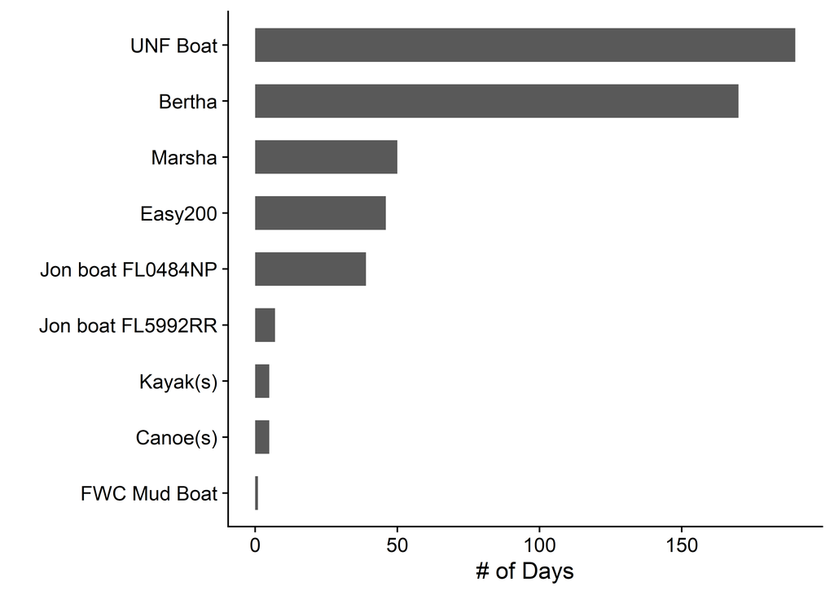

# Captain

The primary captain on the Float Plans completed through the Google Form is Pamela Marcum with 199 boat days. Pam serves as the primary captain *twice* as much as Jimmy Tomazinis (n = 99) and Silas Tanner (n = 93), almost *four times* as much as the previous biologist, Ben Mowbray (n = 50), and *five times* as much as Shannon Dunnigan (n = 37).

| captain | n |
| --- | --- |
| Pamela Marcum | 199 |
| Jimmy Tomazinis | 99 |
| Silas Tanner | 93 |
| Benjamin Mowbray | 50 |
| Shannon Dunnigan | 37 |
| Jessica Lee | 10 |
| Kenneth Rainer | 10 |
| Nikki Dix | 4 |
| Ruben Allen | 4 |
| Multiple Listed | 2 |
| Remo Mondazzi | 2 |
| Ches | 1 |
| Gabriela Canas | 1 |
| Matt Hayes | 1 |
| Michael Dickson | 1 |
| Scott Eastman | 1 |

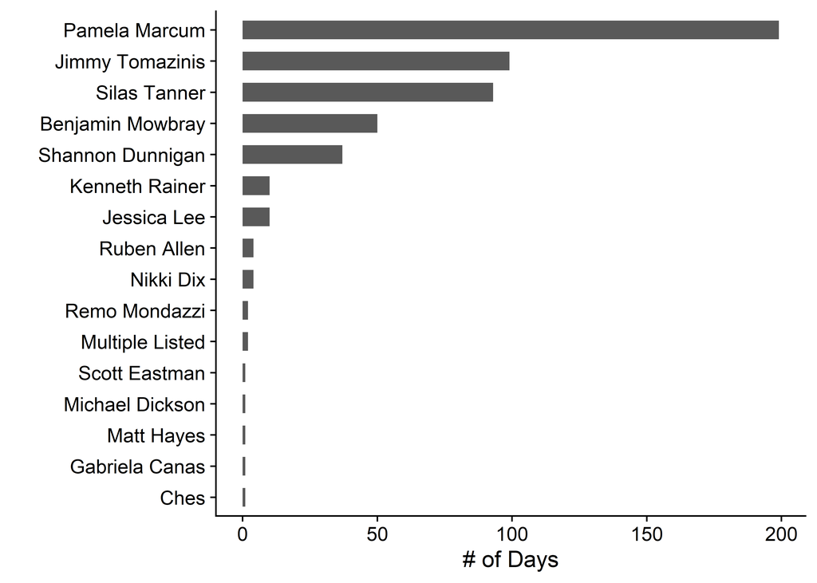

For the top five primary captains in the GTMNERR Float Plans, the vessel preference appears to favor the UNF Boat, which is also the most used vessel for projects. However, Jimmy Tomazinis does not use the UNF Boat, but tends to use “Bertha” and Jon boat (FL0484NP) for his projects.

| captain | vessel_name | n |
| --- | --- | --- |
| Benjamin Mowbray | Bertha | 19 |
| Benjamin Mowbray | Easy200 | 7 |
| Benjamin Mowbray | Marsha | 2 |
| Benjamin Mowbray | UNF Boat | 22 |
| Ches | Bertha | 1 |
| Gabriela Canas | UNF Boat | 1 |
| Jessica Lee | Jon boat FL0484NP | 5 |
| Jessica Lee | Jon boat FL5992RR | 4 |
| Jessica Lee | Kayak(s) | 1 |
| Jimmy Tomazinis | Bertha | 52 |
| Jimmy Tomazinis | Easy200 | 8 |
| Jimmy Tomazinis | FWC Mud Boat | 1 |
| Jimmy Tomazinis | Jon boat FL0484NP | 23 |
| Jimmy Tomazinis | Kayak(s) | 3 |
| Jimmy Tomazinis | Marsha | 11 |
| Jimmy Tomazinis | NA | 1 |
| Kenneth Rainer | Bertha | 8 |
| Kenneth Rainer | Easy200 | 2 |
| Matt Hayes | Bertha | 1 |
| Michael Dickson | UNF Boat | 1 |
| Multiple Listed | Easy200 | 1 |
| Multiple Listed | UNF Boat | 1 |
| Nikki Dix | Jon boat FL0484NP | 4 |
| Pamela Marcum | Bertha | 46 |
| Pamela Marcum | Canoe(s) | 1 |
| Pamela Marcum | Easy200 | 15 |
| Pamela Marcum | Jon boat FL0484NP | 4 |
| Pamela Marcum | Jon boat FL5992RR | 1 |
| Pamela Marcum | Marsha | 34 |
| Pamela Marcum | UNF Boat | 97 |
| Pamela Marcum | NA | 1 |
| Remo Mondazzi | Marsha | 1 |
| Remo Mondazzi | UNF Boat | 1 |
| Ruben Allen | Easy200 | 2 |
| Ruben Allen | UNF Boat | 2 |
| Scott Eastman | Jon boat FL0484NP | 1 |
| Shannon Dunnigan | Bertha | 4 |
| Shannon Dunnigan | Canoe(s) | 1 |
| Shannon Dunnigan | Easy200 | 2 |
| Shannon Dunnigan | Jon boat FL5992RR | 2 |
| Shannon Dunnigan | Kayak(s) | 1 |
| Shannon Dunnigan | UNF Boat | 27 |
| Silas Tanner | Bertha | 39 |
| Silas Tanner | Canoe(s) | 3 |
| Silas Tanner | Easy200 | 9 |
| Silas Tanner | Jon boat FL0484NP | 2 |
| Silas Tanner | Marsha | 2 |
| Silas Tanner | UNF Boat | 38 |

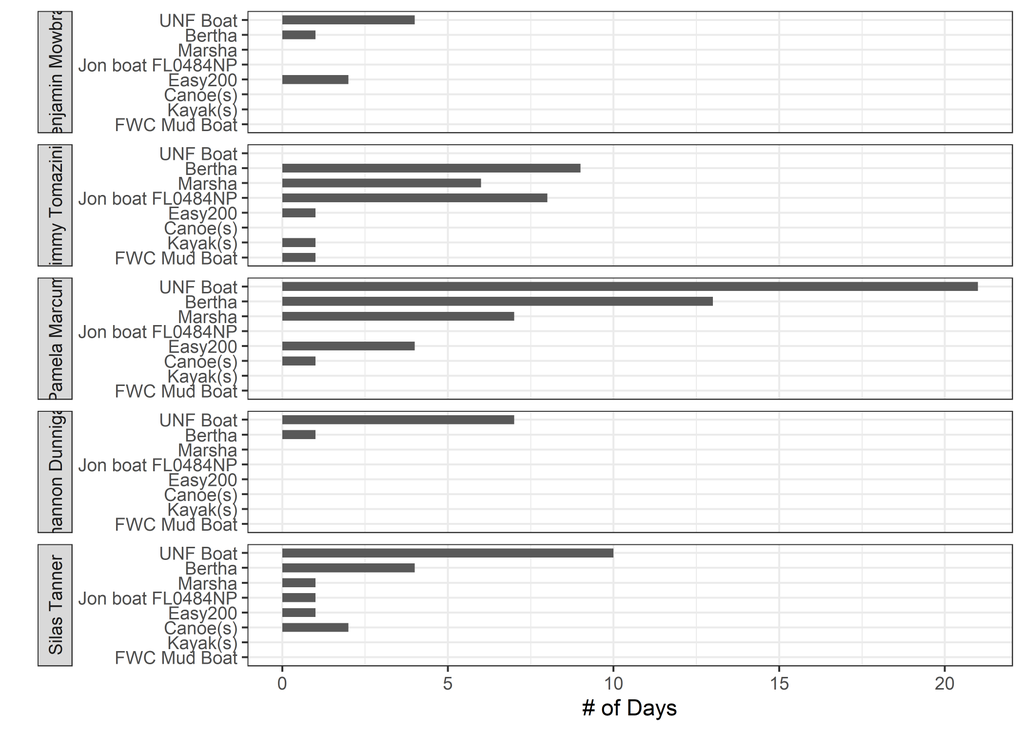

# Use

Vessels are primarily used by staff 96% of the time.

| type | n |
| --- | --- |
| staff | 494 |
| visitor | 13 |
| volunteer | 6 |

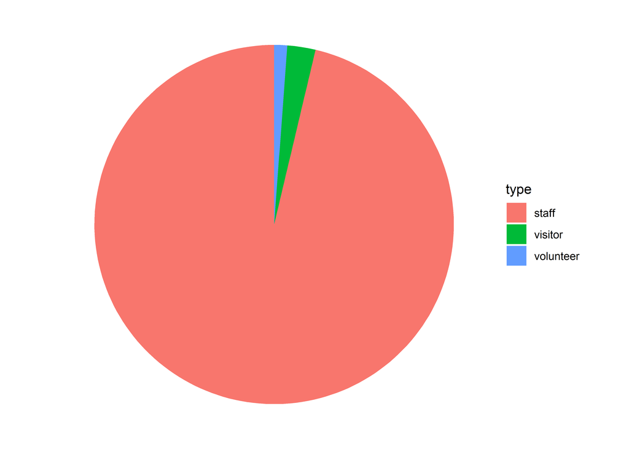